# User Guide

### TUV

The output from the TUV model can be imported either by editing it before import, or by making a simple edit to the output routine of TUV. This function is known to work with TUV version 5.0 output. The output from TUV can contain a variable number of spectra in ‘’parallel’’ columns, which are *melted* into a single column, with a factor with letters as levels, a numeric variable with the zenith angle and a POSIXct column with times. A date needs to be always supplied as the output file from TUV has only time of day information.

```r
tuv.file <-
  system.file("extdata", "usrout.txt",
              package = "photobiologyInOut", mustWork = TRUE)
tuv.spct <- read_tuv_usrout(file = tuv.file,
                            date = ymd("2014-03-21"))
summary(subset(tuv.spct, spct.idx == "A"))
```

```
## Summary of source_spct [482 x 5] object: anonymous
## Wavelength range 280.5-761.5 nm, step 1 nm
## Label:  TUV spectral simulation File: usrout.txt
## Measured on 2014-03-21 12:00:00 UTC
## Measured on 2014-03-21 13:00:00 UTC
## Measured on 2014-03-21 14:00:00 UTC
## Measured on 2014-03-21 15:00:00 UTC
## Measured on 2014-03-21 16:00:00 UTC
## Measured on 2014-03-21 17:00:00 UTC
## Measured on 2014-03-21 18:00:00 UTC
## Measured on 2014-03-21 19:00:00 UTC
## Variables:
##  w.length: Wavelength [nm]
##  s.e.irrad: Spectral energy irradiance [W m-2 nm-1]
## --
##     w.length     spct.idx   s.e.irrad
##  Min.   :280.5   A:482    Min.   :0.000
##  1st Qu.:400.8            1st Qu.:1.216
##  Median :521.0            Median :1.483
##  Mean   :521.0            Mean   :1.322
##  3rd Qu.:641.2            3rd Qu.:1.680
##  Max.   :761.5            Max.   :1.947
##      angle            date
##  Min.   :1.829   Min.   :2014-03-21 12:00:00
##  1st Qu.:1.829   1st Qu.:2014-03-21 12:00:00
##  Median :1.829   Median :2014-03-21 12:00:00
##  Mean   :1.829   Mean   :2014-03-21 12:00:00
##  3rd Qu.:1.829   3rd Qu.:2014-03-21 12:00:00
##  Max.   :1.829   Max.   :2014-03-21 12:00:00
```

```r
tuv.spct
```

```
## Object: source_spct [3,856 x 5]
## containing 8 spectra in long form
## Wavelength range 280.5-761.5 nm, step 1 nm
## Label: TUV spectral simulation File: usrout.txt
## Measured on 2014-03-21 12:00:00 UTC
## Measured on 2014-03-21 13:00:00 UTC
## Measured on 2014-03-21 14:00:00 UTC
## Measured on 2014-03-21 15:00:00 UTC
## Measured on 2014-03-21 16:00:00 UTC
## Measured on 2014-03-21 17:00:00 UTC
## Measured on 2014-03-21 18:00:00 UTC
## Measured on 2014-03-21 19:00:00 UTC
## Variables:
##  w.length: Wavelength [nm]
##  s.e.irrad: Spectral energy irradiance [W m-2 nm-1]
## --
## # A tibble: 3,856 × 5
##   w.length spct.idx s.e.irrad angle date
##      <dbl> <chr>        <dbl> <dbl> <dttm>
## 1     280. A         3.04e-15  1.83 2014-03-21 12:00:00
## 2     282. A         1.16e-13  1.83 2014-03-21 12:00:00
## 3     282. A         1.82e-12  1.83 2014-03-21 12:00:00
## # ℹ 3,853 more rows
```

It is possible to extract individual spectra with subset, or as done here plot them in different panels.

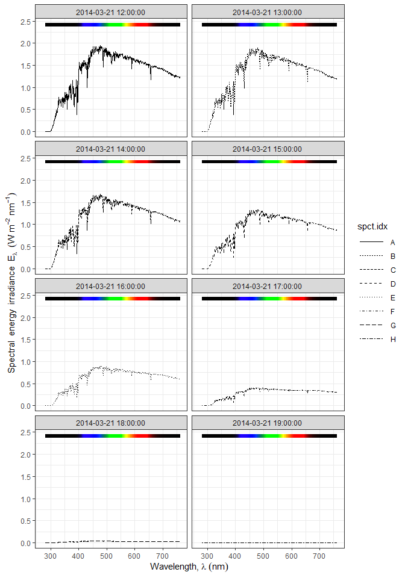

```r
autoplot(tuv.spct, annotations = c("colour.guide")) +
  facet_wrap(~as.character(date), ncol = 2)
```

```r
tuv.mspct <- subset2mspct(tuv.spct)
summary(tuv.mspct)
```

```
## Summary of source_mspct [8 x 1] object: tuv.mspct
## # A tibble: 8 × 8
##   spct.idx class       dim    w.length.min w.length.max
##   <chr>    <chr>       <chr>         <dbl>        <dbl>
## 1 A        source_spct [482 …         280.         762.
## 2 B        source_spct [482 …         280.         762.
## 3 C        source_spct [482 …         280.         762.
## # ℹ 5 more rows
## # ℹ 3 more variables: colnames <list>,
## #   multiple.wl <dbl>, time.unit <Duration>
```

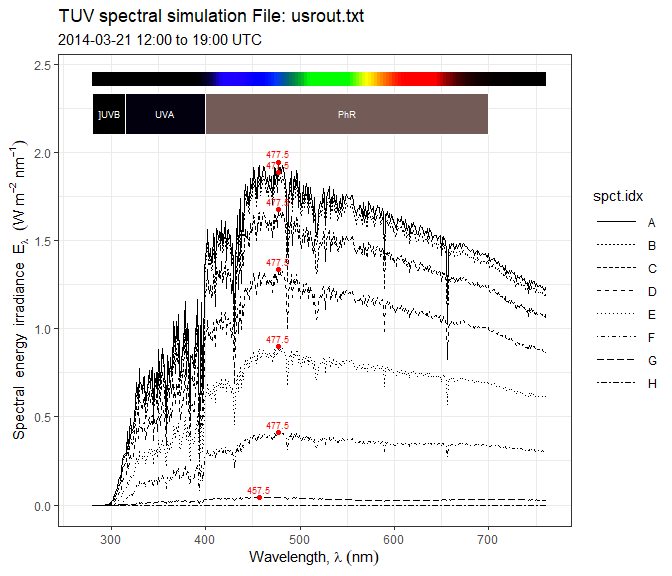

```r
autoplot(tuv.mspct)
```

A file can be directly read into a collection using `read_tuv_usrout2mspct()` which is a simple wrapper.

With the default of `lubridate::today()` date times are ‘mapped’ to the current local date using the time zone of the computer as visible to R. **This is unlikely to be correct!**

```r
tuv_nd.spct <- read_tuv_usrout(file = tuv.file)
when_measured(tuv_nd.spct)
```

```
## [1] "2025-09-24 12:00:00 UTC" "2025-09-24 13:00:00 UTC"
## [3] "2025-09-24 14:00:00 UTC" "2025-09-24 15:00:00 UTC"
## [5] "2025-09-24 16:00:00 UTC" "2025-09-24 17:00:00 UTC"
## [7] "2025-09-24 18:00:00 UTC" "2025-09-24 19:00:00 UTC"
```

### Quick TUV calculator

The files output by the online calculator based on the TUV model, contain at most one spectrum, and arguments to only some parameters can be set by users. However, it is convenient to use when we only need a few simple simulations.

Function `read_qtuv_txt()` can extract spectra and the corresponding metadata from these files. These files do contain date time information and geolocation data when they are supplied as arguments to the calculator interface, otherwise only zenith angle is available.

```r
qtuv.file <-
  system.file("extdata", "qtuv.txt",
              package = "photobiologyInOut", mustWork = TRUE)
qtuv.spct <- read_qtuv_txt(file = qtuv.file)
summary(qtuv.spct)
```

```
## Summary of source_spct [140 x 5] object: qtuv.spct
## Wavelength range 280.5-419.5 nm, step 1 nm
## Label:  Solar spectrum (model simulation). File: qtuv.txt
## Measured on  2015-06-30  UTC
## Variables:
##  w.length: Wavelength [nm]
##  s.e.irrad: Spectral energy irradiance [W m-2 nm-1]
## --
##     w.length       s.e.irrad      s.e.irrad.dir
##  Min.   :280.5   Min.   :0.0000   Min.   :0.00000
##  1st Qu.:315.2   1st Qu.:0.1930   1st Qu.:0.05189
##  Median :350.0   Median :0.4600   Median :0.16540
##  Mean   :350.0   Mean   :0.4439   Mean   :0.18938
##  3rd Qu.:384.8   3rd Qu.:0.6097   3rd Qu.:0.26338
##  Max.   :419.5   Max.   :1.0390   Max.   :0.53710
##  s.e.irrad.diff.down s.e.irrad.diff.up
##  Min.   :0.0000      Min.   :0.00000
##  1st Qu.:0.1387      1st Qu.:0.01930
##  Median :0.2900      Median :0.04600
##  Mean   :0.2545      Mean   :0.04439
##  3rd Qu.:0.3467      3rd Qu.:0.06097
##  Max.   :0.5109      Max.   :0.10390
```

```r
qtuv.spct
```

```
## Object: source_spct [140 x 5]
## Wavelength range 280.5-419.5 nm, step 1 nm
## Label: Solar spectrum (model simulation). File: qtuv.txt
## Measured on 2015-06-30 UTC
## Variables:
##  w.length: Wavelength [nm]
##  s.e.irrad: Spectral energy irradiance [W m-2 nm-1]
## --
## # A tibble: 140 × 5
##   w.length s.e.irrad s.e.irrad.dir s.e.irrad.diff.down
##      <dbl>     <dbl>         <dbl>               <dbl>
## 1     280.  1.34e-14      3.89e-15            9.50e-15
## 2     282.  4.33e-13      1.24e-13            3.09e-13
## 3     282.  5.86e-12      1.66e-12            4.20e-12
## # ℹ 137 more rows
## # ℹ 1 more variable: s.e.irrad.diff.up <dbl>
```

### libRadtran

By default libRadtran’s uvspec writes only spectral irradiances to a text file as output. This is different from ‘TUV’ which by default includes an extensive header with the parameter settings used for the simulation. It is easy to read this simple output file with R’s functions. However, we provide functions, that simplify reading of the files. The output from uvspec varies depending on its input. The main source of differences is the solver routine used. We will provide a separate function for each solver.

For reading this simple output, no special function is needed. We can use `read.table` from base R. Here we read a file with two columns with wavelengths and global spectral energy irradiance (named “eglo” in libRadtran) in $mW\,m^{-2}\,nm^{-1}$. The file was created with one of the ‘uvspec’ examples included with libRadtran, but reducing the output to two columns.

The first few lines of the file look like this:

```
  250.000  0.000000e+00
  251.000  0.000000e+00
  252.000  0.000000e+00
  253.000  0.000000e+00
...
```

```r
uvspec.2col.file <-
  system.file("extdata", "uvspec-plain-2col.dat",
              package = "photobiologyInOut", mustWork = TRUE)
lrt.df <- read.table(file = uvspec.2col.file,
                     col.names = c("w.length", "s.e.irrad"))
uvspec.01.spct <- source_spct(w.length = lrt.df$w.length,
                               s.e.irrad = lrt.df$s.e.irrad * 1e-3)
summary(uvspec.01.spct)
```

```
## Summary of source_spct [3,751 x 2] object: uvspec.01.spct
## Wavelength range 250-4000 nm, step 1 nm
## Variables:
##  w.length: Wavelength [nm]
##  s.e.irrad: Spectral energy irradiance [W m-2 nm-1]
## --
##     w.length      s.e.irrad
##  Min.   : 250   Min.   :0.000000
##  1st Qu.:1188   1st Qu.:0.003808
##  Median :2125   Median :0.023999
##  Mean   :2125   Mean   :0.244546
##  3rd Qu.:3062   3rd Qu.:0.264351
##  Max.   :4000   Max.   :1.744596
```

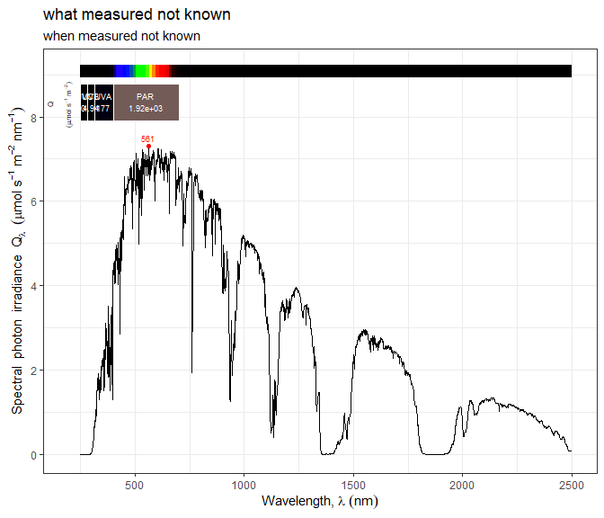

```r
cat(comment(uvspec.01.spct))
autoplot(uvspec.01.spct, range = c(250, 2500), unit.out = "photon")
```

An example using solver `disort` and our function read_uvspec_disort() follows.

The first few lines of the file look like this:

```
  290.000  0.000000e+00  0.000000e+00  0.000000e+00  0.000000e+00  0.000000e+00  0.000000e+00
  291.000  1.046525e-11  4.800521e-06  1.674293e-07  2.374267e-12  5.342789e-07  2.664720e-08
  292.000  5.888299e-10  2.813865e-05  9.814190e-07  1.335888e-10  3.162808e-06  1.561977e-07
  293.000  4.383296e-09  5.764524e-05  2.010660e-06  9.944455e-10  6.522616e-06  3.200065e-07
...
```

```r
uvspec.disort.file <-
  system.file("extdata", "uvspec-disort.dat",
              package = "photobiologyInOut", mustWork = TRUE)
uvspec.02.spct <- read_uvspec_disort(uvspec.disort.file)
summary(uvspec.02.spct)
```

```
## Summary of source_spct [611 x 4] object: uvspec.02.spct
## Wavelength range 290-900 nm, step 1 nm
## Label:  libRadtran spectral simulation File: uvspec-disort.dat
## Variables:
##  w.length: Wavelength [nm]
##  s.e.irrad: Spectral energy irradiance [W m-2 nm-1]
## --
##     w.length     s.e.irrad.dir    s.e.irrad.diff
##  Min.   :290.0   Min.   :0.0000   Min.   :0.00000
##  1st Qu.:442.5   1st Qu.:0.2693   1st Qu.:0.01647
##  Median :595.0   Median :0.3781   Median :0.04204
##  Mean   :595.0   Mean   :0.3269   Mean   :0.06485
##  3rd Qu.:747.5   3rd Qu.:0.4440   3rd Qu.:0.11234
##  Max.   :900.0   Max.   :0.4928   Max.   :0.19479
##    s.e.irrad
##  Min.   :0.0000
##  1st Qu.:0.3237
##  Median :0.4236
##  Mean   :0.3918
##  3rd Qu.:0.5049
##  Max.   :0.6058
```

```r
cat(comment(uvspec.02.spct))
```

```
## libRadtran file 'uvspec-disort.dat' imported on 2025-09-24 17:53:34.467591 UTC
```

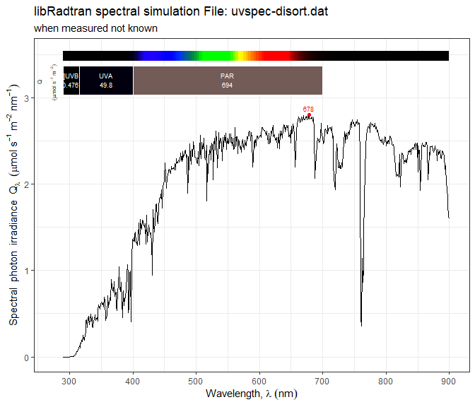

```r
autoplot(uvspec.02.spct, unit.out = "photon")
```

The data contains also estimates of diffuse and direct spectral irradiance. Here we plot the total energy irradiance with a solid line and the diffuse component with a dashed line.

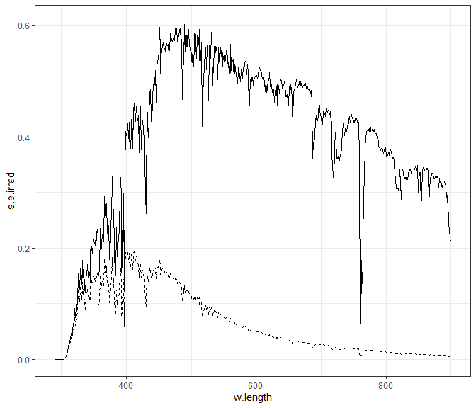

```r
ggplot(uvspec.02.spct) +
  geom_line() +
  geom_line(aes(y = s.e.irrad.diff), linetype = "dashed")
```

The uvspec file used to generate the spectrum read above is:

```
data_files_path uvspec_home/data/
atmosphere_file uvspec_home/data/atmmod/afglms.dat
source solar uvspec_home/data/solar_flux/kurudz_1.0nm.dat
rte_solver disort
mol_abs_param lowtran
deltam on
number_of_streams 6
wavelength 290 900
day_of_year 287
altitude 0.012
albedo_library IGBP
brdf_rpv_type 5
mol_modify O3 288 DU
mol_modify H2O 10 MM
sza 69.4662
sur_temperature 273
```

If we plan to save and reuse the spectral object, it is recommended to append the input file to the comment.

```r
uvspec.disort.inp.file <-
  system.file("extdata", "uvspec-disort.inp",
              package = "photobiologyInOut", mustWork = TRUE)
comment(uvspec.02.spct) <- paste(comment(uvspec.02.spct),
                                 read_file(uvspec.disort.inp.file),
                                 sep = "\n\n")
cat(comment(uvspec.02.spct))
```

```
## libRadtran file 'uvspec-disort.dat' imported on 2025-09-24 17:53:34.467591 UTC
##
## data_files_path uvspec_home/data/
## atmosphere_file uvspec_home/data/atmmod/afglms.dat
## source solar uvspec_home/data/solar_flux/kurudz_1.0nm.dat
## rte_solver disort
## mol_abs_param lowtran
## deltam on
## number_of_streams 6
## wavelength 290 900
## day_of_year 287
## altitude 0.012
## albedo_library IGBP
## brdf_rpv_type 5
## mol_modify O3 288 DU
## mol_modify H2O 10 MM
## sza 69.4662
## sur_temperature 273
```

We give two additional examples, which will most likely need some adjustment by users, as these are for output from libRadtran post-processed to add additional information. These are included in the package because myself and collaborators use these formats heavily. In fact users could develop shell scripts or Perl scripts using the same output format.

### Output enriched with time and date data

In this case the file to be read is similar as above, but including separate columns for direct and diffuse components of the spectral energy irradiance. In addition two columns, one with date strings in ISO format and one with times have been added. The file instead of containing a single spectrum, contains several spectra in long form.

The first few lines of the file look like this:

```
290.000 2015-05-19 11_00_00 0.000000e+00 0.000000e+00
291.000 2015-05-19 11_00_00 0.000000e+00 0.000000e+00
292.000 2015-05-19 11_00_00 0.000000e+00 0.000000e+00
293.000 2015-05-19 11_00_00 1.893645e-05 3.439497e-05
294.000 2015-05-19 11_00_00 1.648530e-04 2.764368e-04
...
```

```r
uvspec.multi.file <-
  system.file("extdata", "uvspec-multi.dat",
              package = "photobiologyInOut", mustWork = TRUE)
lbr.multi.spct <- read_uvspec_disort_vesa(uvspec.multi.file)
print(lbr.multi.spct, n = 5)
```

```
## Object: source_spct [3,055 x 5]
## containing 5 spectra in long form
## Wavelength range 290-900 nm, step 1 nm
## Label: libRadtran spectral simulation File: uvspec-multi.dat
## Measured on 2015-05-19 11:00:00 UTC
## Measured on 2015-05-19 11:01:00 UTC
## Measured on 2015-05-19 11:02:00 UTC
## Measured on 2015-05-19 11:03:00 UTC
## Measured on 2015-05-19 11:04:00 UTC
## Variables:
##  w.length: Wavelength [nm]
##  s.e.irrad: Spectral energy irradiance [W m-2 nm-1]
## --
## # A tibble: 3,055 × 5
##   datetime            w.length s.e.irrad.dir
##   <dttm>                 <dbl>         <dbl>
## 1 2015-05-19 11:00:00      290      0
## 2 2015-05-19 11:00:00      291      0
## 3 2015-05-19 11:00:00      292      0
## 4 2015-05-19 11:00:00      293      1.89e-11
## 5 2015-05-19 11:00:00      294      1.65e-10
## # ℹ 3,050 more rows
## # ℹ 2 more variables: s.e.irrad.diff <dbl>,
## #   s.e.irrad <dbl>
```

### Scripts developed by Anders Lindfors

A model for the simulation of the solar spectrum was developed at the Finnish Meteorological Institute (FMI) by Dr. Anders Lindfors and collaborators and uses functions from ‘libRadtran’ as its engine, but saves some additional metadata to the output file. The main addition is related to the estimation of the effect of clouds.

Functions `read_fmi_cum()` and `read_m_fmi_cum()` can be used to read text files output as daily integrated spectral irradiance. In other words cummulated daily data. Function `read_fmi2mspct()` reads spectral irradiance, extracting multiple sequential spectra from a single file.

The first few lines of the files with cummulated data look like this:

```
# date number_of_scans start_scan stop_scan max_time_gap max_sza_gap warnings
# 20140821 15 3:30:00 17:30:00 60 7.4
# wavelength exposure(J/m2/nm)
2900 0.00000000e+00
2910 2.93132235e-05
2920 7.23526379e-04
...
```

We can read an individual file into a `source_spct` object while adding some metadata read from the file header. In this case values are for daily global spectral energy exposures rather than irradiances. Wavelengths are expressed in Angstroms instead of nanometres.

```r
fmi.file <-
  system.file("extdata", "2014-08-21_cum.hel",
              package = "photobiologyInOut", mustWork = TRUE)
z.spct <- read_fmi_cum(fmi.file)
class_spct(z.spct)
```

```
## [1] "source_spct"  "generic_spct"
```

```r
when_measured(z.spct)
```

```
## [1] "2014-08-21 UTC"
```

```r
z.spct
```

```
## Object: source_spct [511 x 2]
## Wavelength range 290-800 nm, step 1 nm
## Label: File: 2014-08-21_cum.hel
## Measured on 2014-08-21 UTC
## Variables:
##  w.length: Wavelength [nm]
##  s.e.irrad: Spectral energy exposure [J d-1 m-2 nm-1]
## --
## # A tibble: 511 × 2
##   w.length s.e.irrad
##      <dbl>     <dbl>
## 1      290 0
## 2      291 0.0000293
## 3      292 0.000724
## # ℹ 508 more rows
```

With function `read_m_fmi_cum` with an ``m’’ in the name we can read several files each containing a single spectrum. The returned object is a collection of source spectra.

```r
fmi.files <-
  system.file("extdata", c("2014-08-21_cum.hel", "2014-08-21_cum.hel"),
              package = "photobiologyInOut", mustWork = TRUE)
z.mspct <- read_m_fmi_cum(fmi.files)
class(z.mspct)
```

```
## [1] "source_mspct"  "generic_mspct" "list"
```

```r
when_measured(z.mspct)
```

```
## # A tibble: 1 × 2
##   spct.idx           when.measured
##   <fct>              <dttm>
## 1 2014_08_21_cum.hel 2014-08-21 00:00:00
```

```r
z.mspct
```

```
## Object: source_mspct [1 x 1]
## --- Member: 2014_08_21_cum.hel ---
## Object: source_spct [511 x 2]
## Wavelength range 290-800 nm, step 1 nm
## Label: File: 2014-08-21_cum.hel
## Measured on 2014-08-21 UTC
## Variables:
##  w.length: Wavelength [nm]
##  s.e.irrad: Spectral energy exposure [J d-1 m-2 nm-1]
## --
## # A tibble: 511 × 2
##   w.length s.e.irrad
##      <dbl>     <dbl>
## 1      290 0
## 2      291 0.0000293
## 3      292 0.000724
## # ℹ 508 more rows
##
## --- END ---
```

Above we gave the names of the files explicitly, but as we show here, one can build on-the-fly a list of file names matching some pattern. The example below is not run, as the location of example files may vary. The string `"."` should be replaced with the path to the folder where the files to be read are located.

```r
fmi.files <- list.files(".", "*cum.hel")
fmi.files <- paste(".", fmi.files, sep = "")
z1.mspct <- read_m_fmi_cum(fmi.files)
class(z1.mspct)
when_measured(z1.mspct)
z1.mspct
```

One also add a geocode at the time of import (or later).

```r
# because of Google's query limits call will frequently fail without a key
# my.geocode <- ggmap::geocode("Kumpula, Helsinki, Finland", source = "google")
my.geocode <- data.frame(lon = 24.96474, lat = 60.20911)
z2.mspct <-
  read_m_fmi_cum(fmi.files,
                 geocode = my.geocode)
class(z2.mspct)
```

```
## [1] "source_mspct"  "generic_mspct" "list"
```

```r
when_measured(z2.mspct)
```

```
## # A tibble: 1 × 2
##   spct.idx           when.measured
##   <fct>              <dttm>
## 1 2014_08_21_cum.hel 2014-08-21 00:00:00
```

```r
where_measured(z2.mspct)
```

```
## # A tibble: 1 × 4
##   spct.idx             lon   lat address
##   <fct>              <dbl> <dbl> <chr>
## 1 2014_08_21_cum.hel  25.0  60.2 <NA>
```

```r
z2.mspct
```

```
## Object: source_mspct [1 x 1]
## --- Member: 2014_08_21_cum.hel ---
## Object: source_spct [511 x 2]
## Wavelength range 290-800 nm, step 1 nm
## Label: File: 2014-08-21_cum.hel
## Measured on 2014-08-21 UTC
## Variables:
##  w.length: Wavelength [nm]
##  s.e.irrad: Spectral energy exposure [J d-1 m-2 nm-1]
## --
## # A tibble: 511 × 2
##   w.length s.e.irrad
##      <dbl>     <dbl>
## 1      290 0
## 2      291 0.0000293
## 3      292 0.000724
## # ℹ 508 more rows
##
## --- END ---
```

Files with spectral irradiance contain data for multiple spectra stored as text. Each spectrum is delimited at the top by a header line with metadata and at the end by `"end"` in a line by itself.

The first few and last lines for each spectrum look like this:

```
# 20130501 3:30:00 3:30:00 82.656
210.00 2900 0
210.00 2910 0
210.00 2920 0
...
210.00 8480 103.73018
210.00 8490 104.63495
210.00 8500 90.18384
end
...
```

The number of spectra, range of wavelengths and the length of each spectrum can vary. Function `read_fmi2mspct()` uses matching to the delimiters to read all the data in all cases.

```r
fmi.file <-
  system.file("extdata", "2013-05-01.hel",
              package = "photobiologyInOut", mustWork = TRUE)
z3.mspct <- read_fmi2mspct(fmi.file)
class(z3.mspct)[1:2]
```

```
## [1] "source_mspct"  "generic_mspct"
```

```r
when_measured(z3.mspct[[1]])
```

```
## [1] "2013-05-01 03:30:00 UTC"
```

```r
length(z3.mspct)
```

```
## [1] 15
```

```r
names(z3.mspct)
```

```
##  [1] "2013-05-01 03:30:00" "2013-05-01 04:30:00"
##  [3] "2013-05-01 05:30:00" "2013-05-01 06:30:00"
##  [5] "2013-05-01 07:30:00" "2013-05-01 08:30:00"
##  [7] "2013-05-01 09:30:00" "2013-05-01 10:30:00"
##  [9] "2013-05-01 11:30:00" "2013-05-01 12:30:00"
## [11] "2013-05-01 13:30:00" "2013-05-01 14:30:00"
## [13] "2013-05-01 15:30:00" "2013-05-01 16:30:00"
## [15] "2013-05-01 17:30:00"
```

```r
when_measured(z3.mspct[[1]])
```

```
## [1] "2013-05-01 03:30:00 UTC"
```

```r
what_measured(z3.mspct[[1]])
```

```
## [1] "File: 2013-05-01.hel"
```

## Online public repositories of spectral data

Functions for importing spectral data downloaded from repositories.

| R function | Data repository | Version | `class` of value |
| --- | --- | --- | --- |
| read_FReD_csv() | Floral Reflectance db. | 2017-03-19 | reflector_spct |
| read_ASTER_txt() | ASTER spectral lib. | version 2.0 ASCII | reflector_spct |

### FReD Floral Reflectance Database

The files downloaded from FReD do not contain a header, but the first column indicates the flower ID.

```
157, 300, 0.0627119
157, 301, 0.0654036
157, 302, 0.0677941
157, 303, 0.0670396
...
```

```r
fred.file <-
  system.file("extdata", "FReDflowerID_157.csv",
              package = "photobiologyInOut", mustWork = TRUE)
fred.spct <- read_FReD_csv(file = fred.file,
                           label = "Gazania heterochaeta",
                           geocode = data.frame(lat = -28.8751, lon = 17.2293))
```

In this case as there is no metadata present in the file, it needs to be supplied by the user.

```r
fred.spct
```

```
## Object: reflector_spct [401 x 3]
## Wavelength range 300-700 nm, step 1 nm
## Label: File: FReDflowerID_157.csv
## Gazania heterochaeta
## Variables:
##  w.length: Wavelength [nm]
##  Rfr: Total spectral reflectance [/1]
## --
## # A tibble: 401 × 3
##   flower.id w.length    Rfr
##       <dbl>    <dbl>  <dbl>
## 1       157      300 0.0627
## 2       157      301 0.0654
## 3       157      302 0.0678
## # ℹ 398 more rows
```

```r
cat(comment(fred.spct))
```

```
## FReD file 'FReDflowerID_157.csv' imported on 2025-09-24 17:53:35.97443 UTC
```

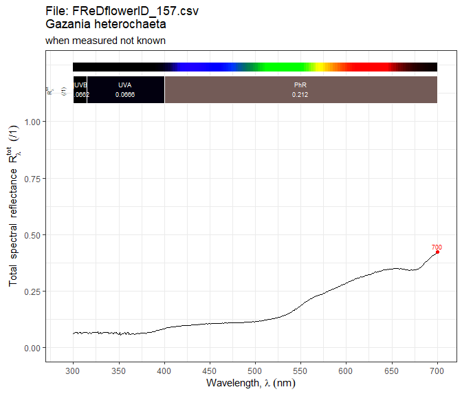

```r
autoplot(fred.spct)
```

### ASTER spectral database

The files downloaded from ASTER contain a 25-lines-long header, but at the moment only the first field is decoded, as the whole header copied as a comment.

```
Name: Dry grass
Type:  Vegetation
Class:  Grasses
Subclass:  Dry grass
Particle Size:  Solid
Sample No.:  drygrass.doc
Owner:  JHU
Wavelength Range:  All
Origin:  The entire spectral range was measured at Johns Hopkins University.

Description:  Dry grass.  Spectra were assembled from two segments; the
bidirectional VNIR and SWIR comprising segment one, and the hemispherical
MWIR and TIR comprising segment two. The VNIR/SWIR spectrum was
measured in the laboratory at JHU with a GER IRIS Mark IV, using a large piece
of sod.  The grass was illuminated from directly above and measured at a
reflectance angle of 60 degrees to avoid viewing the thatch.
Measurement:  Bidirectional and directional hemispherical reflectance.
First Column:  X
Second Column:  Y
X Units:  Wavelength (micrometers)
Y Units:  Reflectance (percent)
First X Value: 0.38049
Last X Value: 14.011
Number of X Values: 2559
Additional Information:  None.

0.38049 14.249
0.38299 14.251
0.38544 14.546
0.38791 14.694
...
```

```r
aster.file <-
  system.file("extdata", "drygrass-spectrum.txt",
              package = "photobiologyInOut", mustWork = TRUE)
aster.spct <- read_ASTER_txt(file = aster.file)
```

The label and comment are set from the file header.

```r
aster.spct
```

```
## Object: reflector_spct [2,559 x 2]
## Wavelength range 380.49-14011 nm, step 0.8-38 nm
## Label: Name: Dry grass
## File: drygrass-spectrum.txt
## Variables:
##  w.length: Wavelength [nm]
##  Rfr: Total spectral reflectance [/1]
## --
## # A tibble: 2,559 × 2
##   w.length   Rfr
##      <dbl> <dbl>
## 1     380. 0.142
## 2     383. 0.143
## 3     385. 0.145
## # ℹ 2,556 more rows
```

```r
cat(comment(aster.spct))
```

```
## ASTER database file 'drygrass-spectrum.txt' imported on 2025-09-24 17:53:36.496782 UTC
## Name: Dry grass
## Type:  Vegetation
## Class:  Grasses
## Subclass:  Dry grass
## Particle Size:  Solid
## Sample No.:  drygrass.doc
## Owner:  JHU
## Wavelength Range:  All
## Origin:  The entire spectral range was measured at Johns Hopkins University.
## Description:  Dry grass.  Spectra were assembled from two segments; the
## bidirectional VNIR and SWIR comprising segment one, and the hemispherical
## MWIR and TIR comprising segment two. The VNIR/SWIR spectrum was
## measured in the laboratory at JHU with a GER IRIS Mark IV, using a large piece
## of sod.  The grass was illuminated from directly above and measured at a
## reflectance angle of 60 degrees to avoid viewing the thatch.
## Measurement:  Bidirectional and directional hemispherical reflectance.
## First Column:  X
## Second Column:  Y
## X Units:  Wavelength (micrometers)
## Y Units:  Reflectance (percent)
## First X Value: 0.38049
## Last X Value: 14.011
## Number of X Values: 2559
## Additional Information:  None.
##
```

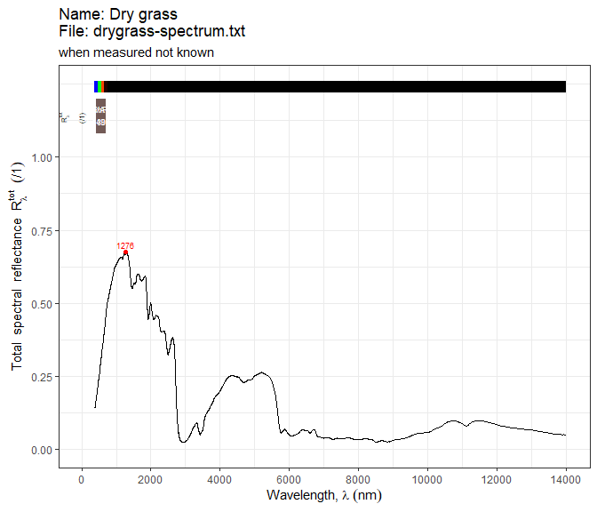

```r
autoplot(aster.spct)
```

## Other R packages

A general way of exchanging data with other R packages or for use with base R functions is to create a matrix from a collection of spectra with `as.matrix()`, or a collection of spectra from a matrix with one of the `as.xxxx_mspct()` methods such as `as.source_spct`. Such methods are defined in package ‘photobiology’ as well as method `join_mspct()` for conversion of collections of spectra into *wide* data frames. However, a matrix is only guaranteed to contain numeric data and a `"dim"` attribute, while conversion to a data frame preserves only part of the metadata. These generic conversions cannot be reversed without loss of information. When possible use the package specific functions as they automate much of the recovery and preservation of metadata.

Functions for exchanging data with *foreign* R packages.

| R function | Foreign R package | Function | `class` of value |
| --- | --- | --- | --- |
| hyperSpec2spct() | ’hyperSpec’ | import | source_spct |
| spct2hyperSpec() | ’hyperSpec’ | export | hyperSpec |
| hyperSpec2mspct() | ’hyperSpec’ | import | source_mspct |
| mspct2hyperSpec() | ’hyperSpec’ | export | hyperSpec |
| colorSpec2spct() | ’colorSpec’ | import | source_spct |
| spct2colorSpec() | ’colorSpec’ | export | colorSpec |
| colorSpec2mspct() | ’colorSpec’ | import | source_mspct |
| mspct2colorSpec() | ’colorSpec’ | export | colorSpec |
| chroma_spct2colorSpec() | ’colorSpec’ | export | colorSpec |
| rspec2mspct() | ’pavo’ | import | source_mspct |

### To ‘hyperSpec’

Can export to `''hyperSpec''` objects only collections of spectra where all members have identical `w.length` vectors, as objects of class `hyperSpec` store a single vector of wavelengths for the whole collection of spectra.

```r
z2.hspct <- mspct2hyperSpec(z2.mspct, "s.e.irrad")
class(z2.hspct)
```

```
## [1] "hyperSpec"
## attr(,"package")
## [1] "hyperSpec"
```

```r
# plot(z2.hspct)
```

### From ‘hyperSpec’

Can import only data with wavelength in nanometres. Other quantities and units are not supported by the ‘photobiology’ classes for spectral data. See package ‘hyperSpec’ vignette “laser” for details on the data and the conversion of the original wavelength units into nanometres.

```r
data(laser)
class(laser)
```

```
## [1] "hyperSpec"
## attr(,"package")
## [1] "hyperSpec"
```

```r
laser
```

```
## hyperSpec object
##    84 spectra
##    3 data columns
##    36 data points / spectrum
## wavelength: lambda/nm [numeric] 404.5828 404.6181 ... 405.8176
## data:  (84 rows x 3 columns)
##    1. t: t / s [numeric] 0 2 ... 5722
##    2. spc: I / a.u. [matrix, array36] 164.650 179.724 ... 112.086
##    3. filename: filename [character] rawdata/laser.txt.gz rawdata/laser.txt.gz ... rawdata/laser.txt.gz
```

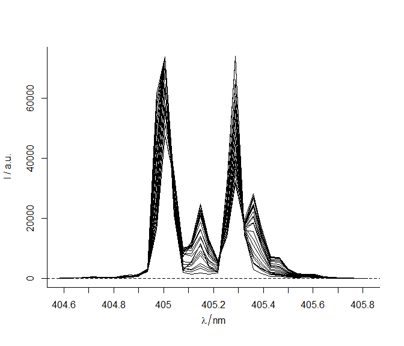

```r
plot(laser)
```

We assume here, that the quantity for the spectral emission of the laser is spectral *energy* irradiance, expressed in $mW\,m^{-2}\,nm^{-1}$. This is likely to be wrong but for the sake of showing how the conversion takes place is irrelevant. The parameter `multiplier` can be passed a numeric argument to rescale the original data. The default multiplier is 1.

```r
wl(laser) <- list (
  wl = 1e7 / (1/405e-7 - wl (laser)),
  label = expression (lambda / nm)
)
laser
```

```
## hyperSpec object
##    84 spectra
##    3 data columns
##    36 data points / spectrum
## wavelength: lambda/nm [numeric] 411.7467 411.7473 ... 411.7677
## data:  (84 rows x 3 columns)
##    1. t: t / s [numeric] 0 2 ... 5722
##    2. spc: I / a.u. [matrix, array36] 164.650 179.724 ... 112.086
##    3. filename: filename [character] rawdata/laser.txt.gz rawdata/laser.txt.gz ... rawdata/laser.txt.gz
```

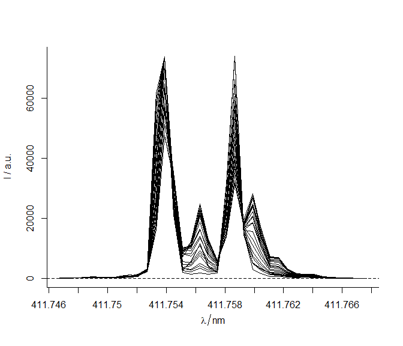

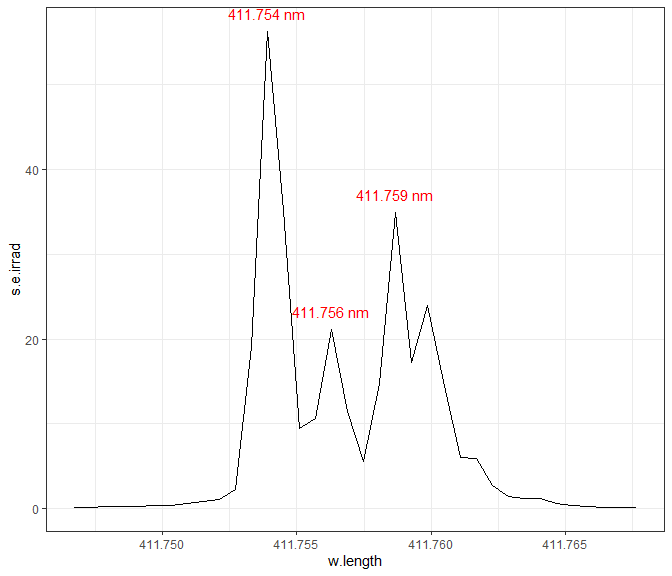

```r
plot(laser)
laser.mspct <-
  hyperSpec2mspct(laser, "source_spct", "s.e.irrad", multiplier = 1e-3)
ggplot(laser.mspct[[1]]) +
  geom_line() +
  stat_peaks(geom = "text", vjust = -1, label.fmt = "%.6g nm", color = "red")
```

### From ‘colorSpec’

```r
# bug that needs to be fixed
fluorescent.mspct <- colorSpec2mspct(colorSpec::Fs.5nm)
print(fluorescent.mspct, n = 3, n.members = 3)
```

```
## Object: source_mspct [12 x 1]
## --- Member: F1 ---
## Object: source_spct [81 x 2]
## Wavelength range 380-780 nm, step 5 nm
## Variables:
##  w.length: Wavelength [nm]
##  s.e.irrad: Spectral energy irradiance [W m-2 nm-1]
## --
## # A tibble: 81 × 2
##   w.length s.e.irrad
##      <dbl>     <dbl>
## 1      380      1.87
## 2      385      2.36
## 3      390      2.94
## # ℹ 78 more rows
## --- Member: F2 ---
## Object: source_spct [81 x 2]
## Wavelength range 380-780 nm, step 5 nm
## Variables:
##  w.length: Wavelength [nm]
##  s.e.irrad: Spectral energy irradiance [W m-2 nm-1]
## --
## # A tibble: 81 × 2
##   w.length s.e.irrad
##      <dbl>     <dbl>
## 1      380      1.18
## 2      385      1.48
## 3      390      1.84
## # ℹ 78 more rows
## --- Member: F3 ---
## Object: source_spct [81 x 2]
## Wavelength range 380-780 nm, step 5 nm
## Variables:
##  w.length: Wavelength [nm]
##  s.e.irrad: Spectral energy irradiance [W m-2 nm-1]
## --
## # A tibble: 81 × 2
##   w.length s.e.irrad
##      <dbl>     <dbl>
## 1      380      0.82
## 2      385      1.02
## 3      390      1.26
## # ℹ 78 more rows
## ..........................
## 9 other member spectra not shown
##
## --- END ---
```

```r
colorSpec2mspct(colorSpec::Hoya)
```

```
## Object: filter_mspct [4 x 1]
## --- Member: R-60 ---
## Object: filter_spct [46 x 2]
## Wavelength range 300-750 nm, step 10 nm
## Rfr (/1): NA, thickness (mm): NA, attenuation mode: NA.
## Variables:
##  w.length: Wavelength [nm]
##  Tfr: Total spectral transmittance [/1]
## --
## # A tibble: 46 × 2
##   w.length   Tfr
##      <dbl> <dbl>
## 1      300     0
## 2      310     0
## 3      320     0
## # ℹ 43 more rows
## --- Member: G-533 ---
## Object: filter_spct [46 x 2]
## Wavelength range 300-750 nm, step 10 nm
## Rfr (/1): NA, thickness (mm): NA, attenuation mode: NA.
## Variables:
##  w.length: Wavelength [nm]
##  Tfr: Total spectral transmittance [/1]
## --
## # A tibble: 46 × 2
##   w.length   Tfr
##      <dbl> <dbl>
## 1      300     0
## 2      310     0
## 3      320     0
## # ℹ 43 more rows
## --- Member: B-440 ---
## Object: filter_spct [46 x 2]
## Wavelength range 300-750 nm, step 10 nm
## Rfr (/1): NA, thickness (mm): NA, attenuation mode: NA.
## Variables:
##  w.length: Wavelength [nm]
##  Tfr: Total spectral transmittance [/1]
## --
## # A tibble: 46 × 2
```

[output cut: 8 more lines]

```
## Wavelength range 300-750 nm, step 10 nm
## Rfr (/1): NA, thickness (mm): NA, attenuation mode: NA.
## Variables:
##  w.length: Wavelength [nm]
##  Tfr: Total spectral transmittance [/1]
## --
## # A tibble: 46 × 2
##   w.length     Tfr
##      <dbl>   <dbl>
## 1      300 0.00003
## 2      310 0.0058
## 3      320 0.081
## # ℹ 43 more rows
##
## --- END ---
```

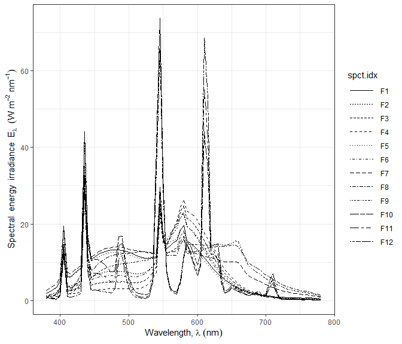

```r
fluorescent.spct <- colorSpec2spct(colorSpec::Fs.5nm)
autoplot(fluorescent.spct, annotations = "")
```

```r
colorSpec2chroma_spct(colorSpec::xyz1931.5nm)
```

```
## Object: chroma_spct [81 x 4]
## Wavelength range 380-780 nm, step 5 nm
## Variables:
##  x: Numeric colour coordinate X
##  y: Numeric colour coordinates Y
##  z: Numeric colour coordinates Z
##  w.length: Wavelength [nm]
## --
## # A tibble: 81 × 4
##        x      y      z w.length
##    <dbl>  <dbl>  <dbl>    <dbl>
## 1 0.0014 0      0.0065      380
## 2 0.0022 0.0001 0.0105      385
## 3 0.0042 0.0001 0.0201      390
## # ℹ 78 more rows
```

### To ‘colorSpec’

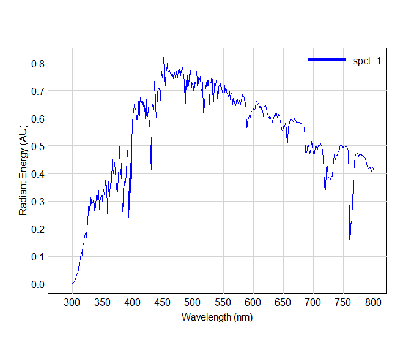

```r
sun.cspec <- spct2colorSpec(sun.spct)
plot(sun.cspec, col = "blue")
```

```r
spct2colorSpec(yellow_gel.spct)
```

```
##
## colorSpec object.   The organization is 'vector'.  Object size is 11632 bytes.
## the object describes 1 transparent materials, and the quantity is 'transmittance'.
## Wavelength range: 190 to 800 nm.  Step size is 1 nm.
##
## 1 spectra
## 611 data points / spectrum
##
##   Material   Min       Max LambdaMax Integral
## 1   spct_1 1e-05 0.9017857       768 260.3202
```

```r
chroma_spct2colorSpec(beesxyzCMF.spct)
```

```
##
## colorSpec object.   The organization is 'matrix'.  Object size is 14560 bytes.
## the object describes a responder to light with 3 output channels, and the quantity is 'power->neural'.
## Wavelength range: 300 to 700 nm.  Step size is 1 nm.
##
## 3 spectra
## 401 data points / spectrum
##
##   Channel   Min Max LambdaMax E.response
## 1       x 0.006   1       560    135.358
## 2       y 0.000   1       435    103.696
## 3       z 0.000   1       340     68.365
```

### Wrappers on ‘colorSpec’ functions.

Functions `spct_CCT()`, `spct_CRI()` and `spct_SSI()` call the respective `compute` functions after converting `source_spct` objects. CCT, CRI and SSI are meaningful for human vision although they are used not only for general illumination but also in photography and cinematography. They can be generalized by overriding the default references from human vision with those of cameras or other visual systems.

```r
spct_CCT(white_led.source_spct) # correlated color temperature
```

```
## [1] 2716.4
## attr(,"Duv")
##      spct_1
## 0.001918272
```

```r
spct_CRI(white_led.source_spct) # color rendition index
```

```
## [1] 80.77449
```

```r
spct_CRI(white_led.source_spct, named = TRUE)
```

```
## white_led.source_spct_1
##                80.77449
```

```r
spct_SSI(white_led.source_spct, sun.spct) # spectral similarity index
```

```
## [1] 37
```